# Data Scrapping HW

Dmitri Bobrikov

11 Октябрь, 2023

# Part 1. Choice & Practical Usage

I have decided to take for scrapping one of my favourite vynil shops - [VinylBox](http://www.vinylbox.ru). For this homework, I have decided to scrap only new products for the last week. It can be explained from two perspective: the personal one and the marketing one. From the personal perpespective, I’m interested in new vinyls that the shop buys and, unfortunately, its site works very slow, so it is faster to run my scrapping code to find some interesting new LPs. From the marketing perspective, scrapping exactly new products is practically useful because it helps to analyze what new vinyls someone’s competitors have, so someone could pretty fast adjust their catalogue and find, for instance, the coloured version of vinyl that VinylBox have only in black version (coloured versions are valued much higher than black versions by vinyl consumers.) So, I can cooperate with [Plastinka Shop](http://www.plastinka.com) and sell them my work.

# Part 2. Variables description

Let’s see the first 10 rows of the gathered data and describe what each variable means.

```r
library(knitr)
library(foreign)
library(dplyr)
library(kableExtra)
library(rCharts)
library(htmlwidgets)
library(ggplot2)

vb = read.csv("~/rrrr/pandan/vinylbox2.csv")
kable(vb[1:10, ], col.names = c('Name', 'Album', "Price", "Country", "Label", "LP Uniqueness"), align = "ccc", caption = "Table 1. Catalogue of New Products on VinylBox")%>%
  kable_styling()
```

Table 1. Catalogue of New Products on VinylBox

| Name | Album | Price | Country | Label | LP Uniqueness |
| --- | --- | --- | --- | --- | --- |
| 801 | 801 Live | 5000 | Japan | Polydor | NA |
| AC/DC | Back In Black | 3900 | Europe | Columbia | NA |
| Action Bronson | Mr. Wonderful | 3800 | Europe | Atlantic | NA |
| Alison Moyet | Alf | 1500 | US | Columbia | NA |
| Atoll | Tertio | 3200 | Japan | Ariola | NA |
| Bananarama | Bananarama | 1500 | US | LondonRecords | NA |
| Barbra Streisand | Barbra Joan Streisand | 2000 | US | Columbia | NA |
| Barbra Streisand | Grand Prix 20 | 2000 | US | CBS/Sony | NA |
| Beatles | A Hard Day’s Night | 1200 | USSR | Мелодия | NA |
| Beatles | A Taste Of Honey | 1000 | USSR | Мелодия | NA |

1. *Name* - the name of the group/band/singer that recorded the album. This variable is useful because it lets us group by singer names to find which albums of the exact singer are available among new products.
2. *Album* - the name of the album that is recorded on vinyl. This variable helps to see the exact LP that is available.
3. *Price* - price of each LP in rubles. With price we can see which LPs are cheaper or more expensive than in other shops. Also, we can check the general distribution of prices on new vinyls.
4. *Country* - country of origin of the LP. Here we can check from which countries LPs come to Russia nowadays.
5. *Label* - label under which the singer(s) created the LP. Here we can see which label produced the LP. It is very crucial, for example, in case of re-recordings. For instance, Taylor Swift re-records her old albums and releases them with the new label, so this variables is crucial to differentiate between old and new records.
6. *LP Uniqueness* - features of the LP, for example, signature of the singer(s) or 2 vinyls inside one box. It helps to track whether some extraordinary features and is useful for both consumers and competitors.

# Part 3. Visualisations

## 1. The most popular singer(s)

Here we are going to check which authors are appeared more frequently compared to others. For this purpose, let’s specify that we will see the authors who appeared more than 2 times.

```r
vb_1 = vb %>% group_by(Name) %>% summarize(count = n()) %>% filter(count > 1)
vb_2 = left_join(vb, vb_1, by = "Name") %>% filter(count > 2)
vb_2$Name = as.factor(vb_2$Name)
vb_2$Name = relevel(vb_2$Name, ref = "Beatles")
vb_2$Name = relevel(vb_2$Name, ref = "Dire Straits")
vb_2$Name = relevel(vb_2$Name, ref = "Paul Mauriat")
vb_2$Name = relevel(vb_2$Name, ref = "Владимир Высоцкий")
```

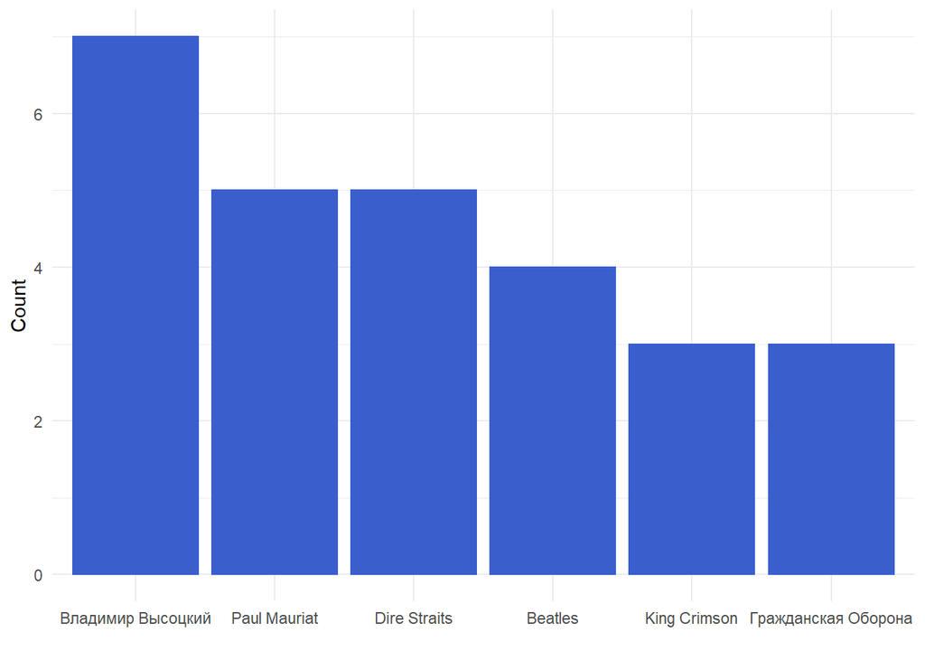

Figure 1.Singers Distribution

```r
ggplot(vb_2, aes( x = Name))+
  geom_bar(colour = '#3A5FCD', fill = '#3A5FCD') +
  xlab(" ")+
  ylab("Count") +
  theme_minimal()
```

Here we can see that “Владимир Высоцкий” appears the most frequently among new LPs.

## 2. Price distribution among countries

Let’s see how prices on LPs are distributed based on countries of origin.

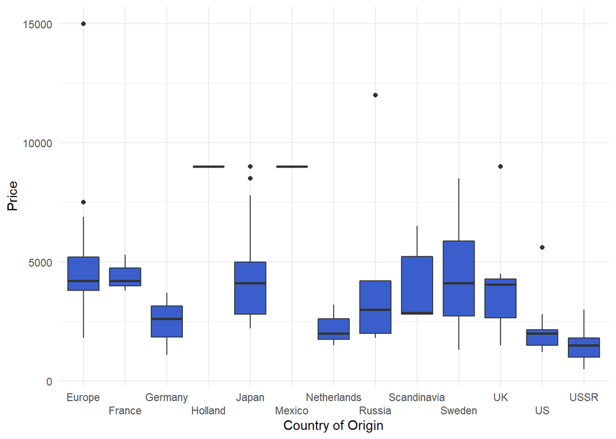

Figure 2. Distribution of prices among countries of origin

```r
vb %>% filter (Price_fine < 20000) %>%
ggplot(aes(x = factor(Country_fine), y=Price_fine))+
  geom_boxplot(fill = '#3A5FCD') +
  facet_grid()+
  xlab("Country of Origin")+
  ylab("Price") +
  scale_x_discrete(guide = guide_axis(n.dodge=2)) +
  theme_minimal()
```

Let’s not count Hollandian and Mexican LPs as they are only in one example. Aside from them, we can see that LP’s from Europe*, France, Japan, Sweden and UK are on average have the same prices and these means are the highest among others.

*Europe as a country of origin means that the distinct country of origin is unknown but it is known that it is somewhere from Europe (or someone in vinylbox had a bad mark on Geography in school).

## 3. General distribution of prices

Also, let’s check the general distribution of prices in the chosen store for new products.

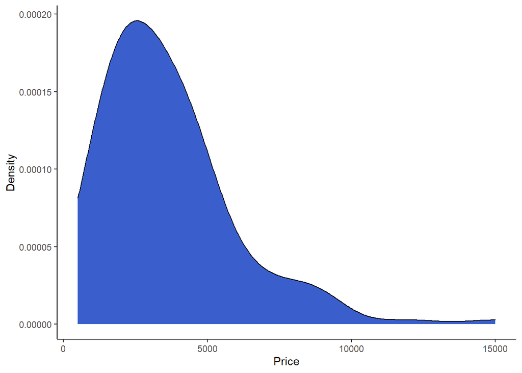

Figure 3. Distribution of Prices

```r
ggplot(vb, aes(x = Price_fine)) +
  geom_density(fill = "#3A5FCD",
               bw = 1000) +
  xlab("Price")+
  ylab("Density")+
  theme_classic()
```

We can see that most of LP’s cost less than 5000 rubles and the highest price is 15000 rubles.

## 4. Top-6 labels

Let’s see the top-6 labels of LPs among new ones.

```r
vb_3 = vb %>% group_by(Label_fine) %>% summarize(count = n()) %>% filter(count > 1)
vb_4 = left_join(vb, vb_3, by = "Label_fine") %>% filter(count > 5)
vb_4$Label_fine = as.factor(vb_4$Label_fine)
vb_4$Label_fine = relevel(vb_4$Label_fine, ref = "WarnerBros.")
vb_4$Label_fine = relevel(vb_4$Label_fine, ref = "Vertigo")
vb_4$Label_fine = relevel(vb_4$Label_fine, ref = "Philips")
vb_4$Label_fine = relevel(vb_4$Label_fine, ref = "Atlantic")
vb_4$Label_fine = relevel(vb_4$Label_fine, ref = "Polydor")
vb_4$Label_fine = relevel(vb_4$Label_fine, ref = "Мелодия")
```

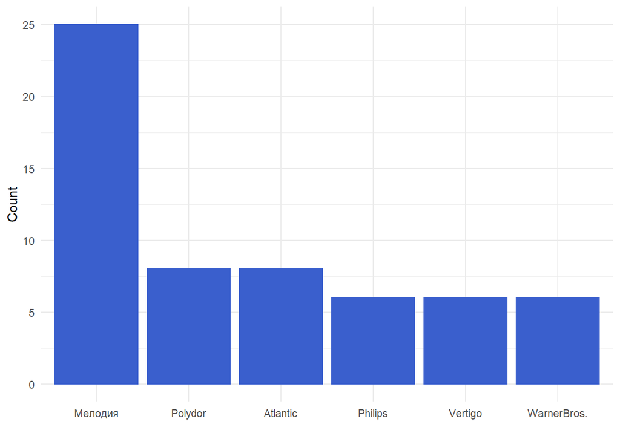

Figure 4. Top-6 labels

```r
ggplot(vb_4, aes( x = Label_fine))+
  geom_bar(colour = '#3A5FCD', fill = '#3A5FCD') +
  xlab(" ")+
  ylab("Count") +
  theme_minimal()
```

The most popular label is “Мелодия”, the second place is shared between “Polydor” and “Atlantic”, and the third place is shared between “Philips”, “Vertigo” and “Warner Bros.”

## 5. LP features

Here we are going to see how many vinyls are coloured, have several LPs, some other** features of nothing special at all.

** Other means here that vinyl can include poster or something else

```r
vb_5 = vb %>% mutate(LP_gen = case_when(LP == "2 LP" | LP == "3 LP" | LP == "2 LP, red vinyl" | LP == "2 LP, clear with red splatter vinyl" ~ "Several LPs",
                                        LP == "'clear with purple and black splatter' vinyl" | LP == "'glow in the dark' vinyl" | LP == "clear vinyl" | LP == "red vinyl" | LP == "metallic silver vinyl" | LP == "white vinyl" | LP == "transparent red vinyl" | LP == "purple vinyl" | LP == "blue vinyl" | LP == "ash red vinyl" | LP == "grey vinyl" | LP == "clear vinyl" | LP == "Original Series Soundtrack) (2 LP, red & purple marbled vinyl" ~ "Coloured vinyl",  LP == "+ poster" | LP == "Led Zeppelin IV" | LP == "На Концертах Владимира Высоцкого 21"| LP == "На Концертах Владимира Высоцкого – 19" | LP == "На Концертах Владимира Высоцкого 15" | LP == "На Концертах Владимира Высоцкого 17" ~ "Other", TRUE  ~ "Nothing special"))
vb_5$LP_gen = as.factor(vb_5$LP_gen)
vb_5$LP_gen = relevel(vb_5$LP_gen, ref = "Several LPs")
vb_5$LP_gen = relevel(vb_5$LP_gen, ref = "Nothing special")
```

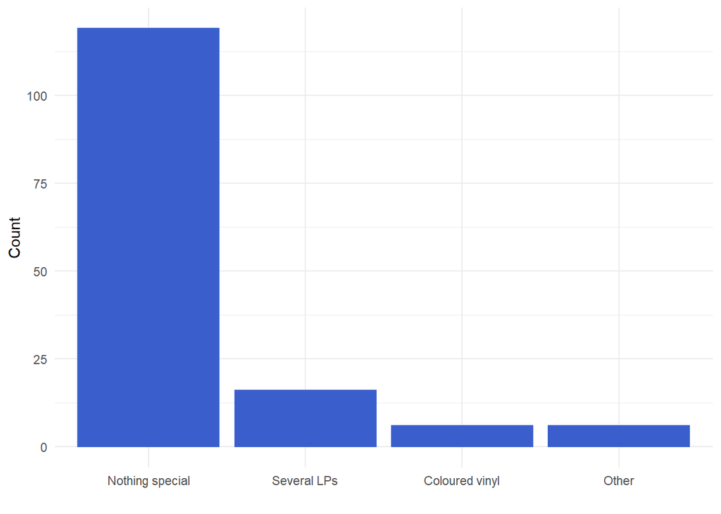

Figure 4. LP features

```r
ggplot(vb_5, aes( x = LP_gen))+
  geom_bar(colour = '#3A5FCD', fill = '#3A5FCD') +
  xlab(" ")+
  ylab("Count") +
  theme_minimal()
```

We can see that mostly there is nothing special among vinyls, though there are some cases when they have several LPs or they are coloured.

# Part 4. Data scrapping process

I chose RSelenium to scrap the data. I started from the setup that included loading packages, starting the server (in firefox browser and not chrome because my version of chrome is not working with Rselenium), creating a client object, opening the browser, adjusting the window and navigating to the website for scrapping.

```
# load packages
library(tidyverse)
library(RSelenium)
library(netstat)

# start the server
rs_driver_object <- rsDriver(browser="firefox", port=4555L, verbose=F, chromever = NULL)

# create a client object
remDr <- rs_driver_object$client

# open a browser
remDr$open()

# maximize window
remDr$maxWindowSize()

# navigate to website
remDr$navigate('http://www.vinylbox.ru//')
```

Then I opened in Chrome browser the chosen website and inspected it with “Selector Gadget” plagin to find the path to the “New Products” button (I have used Xpath here).

[figure not shown]

This way

Then I created an object that clicks on this button.

```
remDr$findElement(using = 'xpath', '//*[(@id = "iceMenu_294")]//*[contains(concat( " ", @class, " " ), concat( " ", "icemega_nosubtitle", " " ))]')$clickElement()
```

Then I inspected with “Selector Gadget” elements on the webpage.

[figure not shown]

This way

Inspecting one by one element I created objects that help to gather prices, singer(s), album titles, labels and countries of origin of LPs and saving them.

```
prices <- remDr$findElements(using = 'class name', 'jshop_price')
price_values <- lapply(prices, function (x) x$getElementText()) %>%
  unlist()

names <- remDr$findElements(using = 'class name', 'name')
names_values <- lapply(names, function (x) x$getElementText()) %>%
  unlist()

albums <- remDr$findElements(using = 'class name', 'description')
albums_values <- lapply(albums, function (x) x$getElementText()) %>%
  unlist()

labels <- remDr$findElements(using = 'xpath', '//*[contains(concat( " ", @class, " " ), concat( " ", "extra_fields", " " ))]//div[(((count(preceding-sibling::*) + 1) = 1) and parent::*)]')
labels_values <- lapply(labels, function (x) x$getElementText()) %>%
  unlist()

country <- remDr$findElements(using = 'class name', 'extra_fields')
country_values <- lapply(country, function (x) x$getElementText()) %>%
  unlist()
```

Then I created the dataframe with all the information

```
data <- do.call(rbind, Map(data.frame, Name=names_values, Country=country_values, Price = price_values, Album = albums_values, Label = labels_values))
```

and made some manipulations with data:

1. Created a clean variable with prices as initially it had “rubles” in each row.

```
data$Price_fine = data$Price %>%
  str_replace_all(".00 руб.", "") %>%
  str_replace_all(" ", "") %>%
  as.numeric()
```

2. Created a clean variable with labels as initially it had “Лейбл:” in each row.

```
data$Label_fine = data$Label %>%
  str_replace_all("Лейбл: ", "") %>%
  str_replace_all(" ", "")
```

```
data$Country_fine = data$Country %>%
  word(-1)
```

4. Created a pre-final dataframe with clean data

```
df = data %>% select(Name, Album, Price_fine, Country_fine, Label_fine)
```

5. Created a function for pulling the data from parentheses in album titles as there were feauters of the albums.

```
ex_num <- function(data){
  str_extract(data, "(?<=\\().*(?=\\))")
}
```

6. Created a final dataframe, using the function.

```
df2 <- df %>%
  mutate(LP = ex_num(Album))
```

7. Finally, saved the data as csv file for analysis.

```
write.csv(df2, "C:\\Users\\beave\\OneDrive\\Documents\\rrrr\\pandan\\vinylbox2.csv", row.names=F)
```

As the last step, I turned off the server.

```
system("taskkill /im java.exe /f")
```